# 219021675_assignment1_solution(5)

## **Importing libraries**

```python
%tensorflow_version 2.x
import tensorflow as tf
print(tf.__version__)
import tensorflow_datasets  as tfds
print(tfds.__version__)
import scipy
import numpy as np
import pandas as pd
from scipy import optimize
from tensorflow import keras
import IPython.display
import PIL.Image
from tensorflow.keras import models
from tensorflow.keras import layers
import matplotlib.pyplot as plt
from keras.utils import to_categorical
from tensorflow.keras import optimizers
from tensorflow.keras.callbacks import TensorBoard
from keras import regularizers
from keras.optimizers import Adam
from keras.optimizers import RMSprop
```

```
2.2.0-rc3
2.1.0
```

## **Task 1 Load the data**

### 1.1 Loading the Fashion MNIST dataset from keras

```python
#Clear any logs from previous runs
import datetime
!rm -rf ./logs/
```

```python
from tensorflow.keras.datasets import fashion_mnist
(train_images, train_labels), (test_images, test_labels) = fashion_mnist.load_data()
```

```
Downloading data from https://storage.googleapis.com/tensorflow/tf-keras-datasets/train-labels-idx1-ubyte.gz
Downloading data from https://storage.googleapis.com/tensorflow/tf-keras-datasets/train-images-idx3-ubyte.gz
Downloading data from https://storage.googleapis.com/tensorflow/tf-keras-datasets/t10k-labels-idx1-ubyte.gz
Downloading data from https://storage.googleapis.com/tensorflow/tf-keras-datasets/t10k-images-idx3-ubyte.gz
```

```python
class_names = ['T-shirt/top', 'Trouser', 'Pullover', 'Dress', 'Coat',
               'Sandal', 'Shirt', 'Sneaker', 'Bag', 'Ankle boot']
```

## **Task 2 Understand the data**

### Display 100 images from the train set in the form of 10x10 matrix.

[figure not shown]

```python
plt.figure(figsize=(15, 15))
for i in range(100):
  images = np.random.randint(0, train_labels.shape[0])
  plt.subplot(10, 10, i+1)
  plt.xticks([])
  plt.yticks([])
  plt.grid('off')
  plt.imshow(train_images[images], cmap=plt.cm.binary)
  plt.xlabel(class_names[train_labels[images]])
plt.show()
```

### 2.1 What are the unique labels in this dataset?

```python
print("Unique labels in training set are", format(np.unique(train_labels)))
print("Unique labels in test set are", format(np.unique(test_labels)))
```

```
Unique labels in training set are [0 1 2 3 4 5 6 7 8 9]
Unique labels in test set are [0 1 2 3 4 5 6 7 8 9]
```

### 2.2 How many training images and how many test images?

```python
print("Number of training images are", format(len(train_images)))
print("Number of test images are", format(len(test_images)))
```

```
Number of training images are 60000
Number of test images are 10000
```

### 2.3 What is the size of each image?

```python
print("Train images shape is",format(train_images[0].shape))
print("Test images shape is",format(test_images[0].shape))
```

```
Train images shape is (28, 28)
Test images shape is (28, 28)
```

### 2.4 Find out the numeric range of the input. Do we need to rescale the input?

```python
print("Numeric range of training input is", format(train_images.max() - train_images.min()))
print("Numeric range of test input is", format(test_images.max() - test_images.min()))
```

```
Numeric range of training input is 255
Numeric range of test input is 255
```

If we input values to neural network which are much larger than the initial values taken by the weights of a network or data that is heterogeneous (for example, data where one feature is in the range 0–1 and another is in the range 100–200). Then, this will trigger large gradient updates that will prevent the network from converging. To make learning easier for the network, we should take small values (prefereably in 0-1 range) and this range should be homogenous for values in all features. We have grey scale image as input, thus range of values will be between 0-255 (black - white) which is heterogenous. Thus, we need to rescale the input.

### 2.5 In our problem, what are the shapes of input tensors and target tensors? Do you need to reshape the input?

```python
print("Shape of Training input tenshors:{}\nShape of Test input tenshors:{}".format(tf.shape(train_images),tf.shape(test_images)))
print("Rank of training input is",format(tf.rank(train_images)))
print("Rank of test input is",format(tf.rank(test_images)))
```

```
Shape of Training input tenshors:[60000    28    28]
Shape of Test input tenshors:[10000    28    28]
Rank of training input is 3
Rank of test input is 3
```

Images typically have three dimensions namely; height, weight, and color depth. Data is of grey scale image which has a single color channel, thus it can be stored in 2D tensors. Also, dense layers are used in the network to extract representation out of the data. As name suggests these layers are densely connected or full connected and if the input has rank greater than 2, then it needs to be flattened i.e. reshape to 2D. Thus, we need to reshape the input.

## **Task 3 Construct an input pipeline**

### 3.1 Exploring data

```python
#Function to check balance (frequency) of the data
def label_frequency(data):
  #Converting labels into dataframe
  df_data = pd.DataFrame(data)
  #Counting frequency of each label
  label_freq = df_data[0].value_counts()
  #Total number of samples
  total_sample = len(df_data)

  # Count the number of items in each class
  for i in range(len(label_freq)):
    label = class_names[label_freq.index[i]]
    label_code = label_freq.index[i]
    count = label_freq.values[i]
    percent = (count / total_sample) * 100
    print("{:<20s}: {}:  {} or {}%".format(label, label_code, count, percent))
```

```python
#Frequency distribution of training labels
label_frequency(train_labels)
```

```
Ankle boot          : 9:  6000 or 10.0%
Bag                 : 8:  6000 or 10.0%
Sneaker             : 7:  6000 or 10.0%
Shirt               : 6:  6000 or 10.0%
Sandal              : 5:  6000 or 10.0%
Coat                : 4:  6000 or 10.0%
Dress               : 3:  6000 or 10.0%
Pullover            : 2:  6000 or 10.0%
Trouser             : 1:  6000 or 10.0%
T-shirt/top         : 0:  6000 or 10.0%
```

```python
#Frequency distribution of training labels
label_frequency(test_labels)
```

```
Sneaker             : 7:  1000 or 10.0%
Shirt               : 6:  1000 or 10.0%
Sandal              : 5:  1000 or 10.0%
Coat                : 4:  1000 or 10.0%
Dress               : 3:  1000 or 10.0%
Pullover            : 2:  1000 or 10.0%
Ankle boot          : 9:  1000 or 10.0%
Trouser             : 1:  1000 or 10.0%
Bag                 : 8:  1000 or 10.0%
T-shirt/top         : 0:  1000 or 10.0%
```

### 3.2 Pre-processing data

```python
#Reshaping training and test images
train_images = train_images.reshape((60000, 28 * 28))
train_images = train_images.astype('float32') / 255

test_images = test_images.reshape((10000, 28 * 28))
test_images = test_images.astype('float32') / 255

#1-hot-coding for labels
train_labels = to_categorical(train_labels)
test_labels = to_categorical(test_labels)

print("Training shape{}\nTest data shape{}".format((train_images.shape),(test_images.shape)))
print("\nUnique training labels{}\nUnique test labels{}".format((np.unique(train_labels)),(np.unique(test_labels))))
```

```
Training shape(60000, 784)
Test data shape(10000, 784)

Unique training labels[0. 1.]
Unique test labels[0. 1.]
```

### 3.3 Creating training, validation, test data and tf.data pipeline

```python
#Splitting training data into training and validation dataset
from sklearn.model_selection import train_test_split
X_train, X_val, Y_train, Y_val = train_test_split(train_images, train_labels, test_size = 0.2, random_state = 12345)

print("Validation images shape", format(X_val.shape))
print("Validation labels shape", format(Y_val.shape))
print("Training images shape", format(X_train.shape))
print("Training labels shape", format(Y_train.shape))
```

```
Validation images shape (12000, 784)
Validation labels shape (12000, 10)
Training images shape (48000, 784)
Training labels shape (48000, 10)
```

```python
#Constructing tensorflow input pipeline
train_dataset = tf.data.Dataset.from_tensor_slices((X_train, Y_train))
train_dataset = train_dataset.shuffle(buffer_size=512, seed=14).batch(512)

test_dataset = tf.data.Dataset.from_tensor_slices((test_images, test_labels))
test_dataset = test_dataset.batch(512)

val_dataset = tf.data.Dataset.from_tensor_slices((X_val, Y_val))
val_dataset = val_dataset.batch(512)
```

## **Task 4 Construct a deep forward neural network**

### 4.1 Setting up a model for training

#### **Output layer:**

##### 1. We have 10 output nodes as we have converted labels in categorical variable using 1-hot-coding.

##### 2. We have used softmax activation function which will provide probability over 10 nodes (i.e. over 0's and 1's) summing to 1.

#### **Hidden layer:**

##### 1. Two hidden layers with 256 nodes and relu activation each are created. Number of hidden layers and nodes are selected arbiteraly to start with. Relu activation function is used as it considers zero for negative inputs, but pixels does not have negative input and is efficient than sigmoid and tanh function.

#### **Input layer:**

##### 1. Input layer unit's is 784 and input size is 28*28

##### a) Loss function used is categorical_crossentropy as label is a multiclass variable with 1-hot-coding. With integer coding, we could have used sparse categorical_crossentropy.

##### b) Accuracy metrics is used as we need to maximize accuracy whilst minimizing loss function.

##### c) RMSProp optimizer is used as which has better convergence speed and quality.

```python
import datetime
#Building architect of the network
model = models.Sequential()
model.add(layers.Dense(256, activation='relu',input_shape=[28*28]))
model.add(layers.Dense(256, activation='relu'))
model.add(layers.Dense(10, activation='softmax'))

#Creating log directory and TensorBoard
log_dir = "logs/fit/" + datetime.datetime.now().strftime("%Y%m%d-%H%M%S")
tensorboard = tf.keras.callbacks.TensorBoard(log_dir=log_dir, histogram_freq=1)
```

```python
#Creating model compiler
model.compile(optimizer=optimizers.RMSprop(lr=0.001),
              loss='categorical_crossentropy',
              metrics=['accuracy'])
```

```python
#Model Structure using summary()
model.summary()
```

```
Model: "sequential"
_________________________________________________________________
Layer (type)                 Output Shape              Param #
=================================================================
dense (Dense)                (None, 256)               200960
_________________________________________________________________
dense_1 (Dense)              (None, 256)               65792
_________________________________________________________________
dense_2 (Dense)              (None, 10)                2570
=================================================================
Total params: 269,322
Trainable params: 269,322
Non-trainable params: 0
_________________________________________________________________
```

```python
#Model structure using utils
keras.utils.plot_model(model)
```

[output not shown]

### 4.2 Fitting the model

##### 1. Training batch size is 512

##### 2. Number of Epochs are 1000

##### 3. Learning rate is 0.001

```python
#Fitting model on training and validation dataset
history = model.fit(train_dataset,
                    epochs = 1000,
                    validation_data=val_dataset,
                    callbacks=[tensorboard])
```

```
Average training accuracy across all epochs is 0.9924
Average validation accuracy across all epochs is 0.8998
```

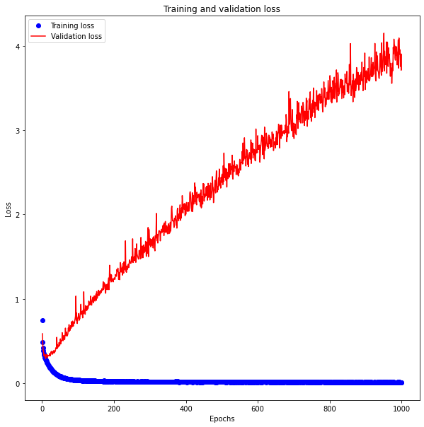

```python
#Evaluating model over training and validation dataset
acc = history.history['accuracy']
val_acc = history.history['val_accuracy']
loss = history.history['loss']
val_loss = history.history['val_loss']

print("Average training accuracy across all epochs is",format(round(sum(acc)/len(acc),4)))
print("Average validation accuracy across all epochs is",format(round(sum(val_acc)/len(val_acc),4)))


#Plotting training and validation loss with number of epochs
plt.figure(figsize=(10, 10))
epochs = range(1, len(loss) + 1)
plt.plot(epochs, loss, 'bo', label='Training loss')
plt.plot(epochs, val_loss, 'b', label='Validation loss', color = 'red')
plt.title('Training and validation loss')
plt.xlabel('Epochs')
plt.ylabel('Loss')
plt.legend()
plt.show()
```

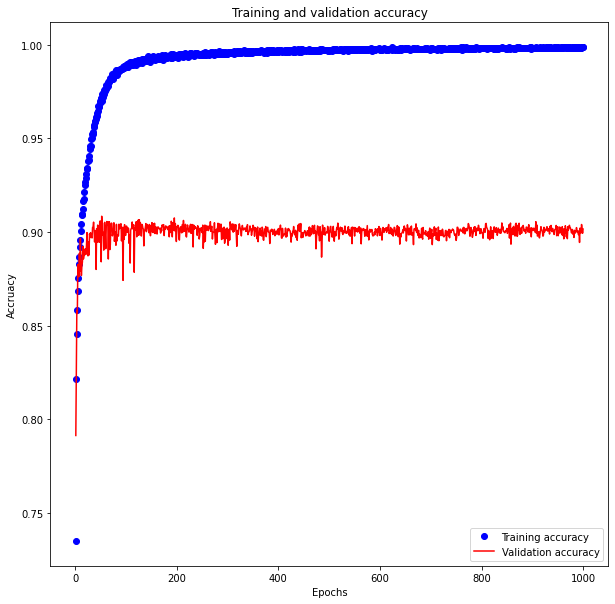

```python
#Plotting training and validation accuracy with number of epochs
plt.figure(figsize=(10, 10))
epochs = range(1, len(acc) + 1)
plt.plot(epochs, acc, 'bo', label='Training accuracy')
plt.plot(epochs, val_acc, 'b', label='Validation accuracy', color = 'red')
plt.title('Training and validation accuracy')
plt.xlabel('Epochs')
plt.ylabel('Accruacy')
plt.legend()
plt.show()
```

##### **1.Overfitting or underfitting**

In loss vs epochs graph we can see that validation loss has increased continuously till 4 and training loss reduced constantly till ~zero. In accuracy vs epochs graph we can see that validation accuracy has been constant around 90% whereas training accuracy started below validation accuracy but reached closed to 100% in 200 epochs. Average training accuracy is 99% and validation accuracy is 90%. Based on these evidences we can say that model is overfitting. Probable reasons might be data is too noisy which has been identified by the model for training data and/or model is overly complex with too many parameters.

### **4.3 Check the convergence through gradient using TensorBoard**

```python
#Launching tensorboard
%reload_ext tensorboard
%tensorboard --logdir logs/fit
```

```
Output hidden; open in https://colab.research.google.com to view.
```

##### **1.Do you see vanishing or exploding gradients?**

```python
outputTensor = model.output
listOfVariableTensors = model.trainable_weights
```

```python
from keras import backend as k
gradients = k.gradients(outputTensor, listOfVariableTensors)
```

```python
grads=k.gradients(loss, train_images)[0]
```

```python
keras.get
```

## **Task 5 Fine-tuning the model**

###### Fitting base model on test dataset

```python
#Base model accuracy on test dataset
model_eval = model.evaluate(test_images, test_labels)
```

[output not shown]

###### 1 Trial model - Reduced model

Since model is overfitting which might be due to complex model. Thus, in first trial model, we will simplify the model by reducing one hidden layer and reduce units to 128.

```python
trial_01 = models.Sequential()
trial_01.add(layers.Dense(128, activation='relu',input_shape=[28*28]))
trial_01.add(layers.Dense(10, activation='softmax'))

trial_01.compile(optimizer=optimizers.RMSprop(lr=0.001),
              loss='categorical_crossentropy',
              metrics=['accuracy'])
```

```python
trial_01.summary()
```

```
Model: "sequential_1"
_________________________________________________________________
Layer (type)                 Output Shape              Param #
=================================================================
dense_3 (Dense)              (None, 128)               100480
_________________________________________________________________
dense_4 (Dense)              (None, 10)                1290
=================================================================
Total params: 101,770
Trainable params: 101,770
Non-trainable params: 0
_________________________________________________________________
```

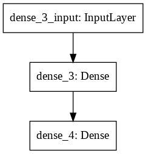

```python
keras.utils.plot_model(trial_01)
```

```python
history_trial_01 = trial_01.fit(train_dataset,
                    epochs = 1000,
                    validation_data=val_dataset,
                    callbacks=[tensorboard])
```

```
Average training accuracy across all epochs is 0.9877
Average validation accuracy across all epochs is 0.8944
```

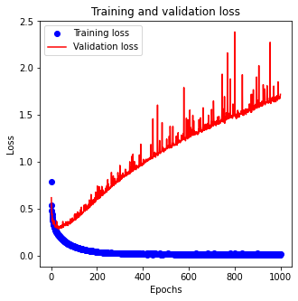

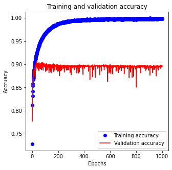

```python
#Evaluating model over training and validation dataset
acc = history_trial_01.history['accuracy']
val_acc = history_trial_01.history['val_accuracy']
loss = history_trial_01.history['loss']
val_loss = history_trial_01.history['val_loss']

print("Average training accuracy across all epochs is",format(round(sum(acc)/len(acc),4)))
print("Average validation accuracy across all epochs is",format(round(sum(val_acc)/len(val_acc),4)))


#Plotting training and validation loss with number of epochs
plt.figure(figsize=(5, 5))
epochs = range(1, len(loss) + 1)
plt.plot(epochs, loss, 'bo', label='Training loss')
plt.plot(epochs, val_loss, 'b', label='Validation loss', color = 'red')
plt.title('Training and validation loss')
plt.xlabel('Epochs')
plt.ylabel('Loss')
plt.legend()
plt.show()

#Plotting training and validation accuracy with number of epochs
plt.figure(figsize=(5, 5))
epochs = range(1, len(acc) + 1)
plt.plot(epochs, acc, 'bo', label='Training accuracy')
plt.plot(epochs, val_acc, 'b', label='Validation accuracy', color = 'red')
plt.title('Training and validation accuracy')
plt.xlabel('Epochs')
plt.ylabel('Accruacy')
plt.legend()
plt.show()
```

```python
trial_01_eval = trial_01.evaluate(test_images, test_labels)
```

##### 2 Trial model - Batch normalisation

```python
trial_02 = keras.models.Sequential([
keras.layers.Dense(128, activation="relu",input_shape=[28*28]),
keras.layers.BatchNormalization(),
keras.layers.Dense(128, activation="relu"),
keras.layers.BatchNormalization(),
keras.layers.Dense(10, activation="softmax")
])


trial_02.compile(optimizer=optimizers.RMSprop(lr=0.01),
              loss='categorical_crossentropy',
              metrics=['accuracy'])
```

```python
trial_02.summary()
```

```
Model: "sequential_2"
_________________________________________________________________
Layer (type)                 Output Shape              Param #
=================================================================
dense_5 (Dense)              (None, 128)               100480
_________________________________________________________________
batch_normalization (BatchNo (None, 128)               512
_________________________________________________________________
dense_6 (Dense)              (None, 128)               16512
_________________________________________________________________
batch_normalization_1 (Batch (None, 128)               512
_________________________________________________________________
dense_7 (Dense)              (None, 10)                1290
=================================================================
Total params: 119,306
Trainable params: 118,794
Non-trainable params: 512
_________________________________________________________________
```

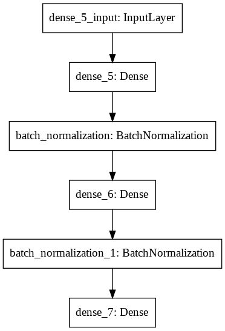

```python
keras.utils.plot_model(trial_02)
```

```python
history_trial_02 = trial_02.fit(train_dataset,
                    epochs = 1000,
                    validation_data=val_dataset,
                    callbacks=[tensorboard])
```

```
Average training accuracy across all epochs is 0.9906
Average validation accuracy across all epochs is 0.8781
```

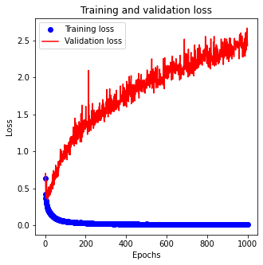

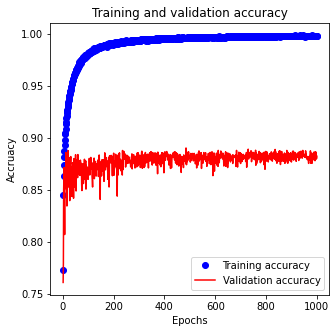

```python
#Evaluating model over training and validation dataset
acc = history_trial_02.history['accuracy']
val_acc = history_trial_02.history['val_accuracy']
loss = history_trial_02.history['loss']
val_loss = history_trial_02.history['val_loss']

print("Average training accuracy across all epochs is",format(round(sum(acc)/len(acc),4)))
print("Average validation accuracy across all epochs is",format(round(sum(val_acc)/len(val_acc),4)))


#Plotting training and validation loss with number of epochs
plt.figure(figsize=(5, 5))
epochs = range(1, len(loss) + 1)
plt.plot(epochs, loss, 'bo', label='Training loss')
plt.plot(epochs, val_loss, 'b', label='Validation loss', color = 'red')
plt.title('Training and validation loss')
plt.xlabel('Epochs')
plt.ylabel('Loss')
plt.legend()
plt.show()

#Plotting training and validation accuracy with number of epochs
plt.figure(figsize=(5, 5))
epochs = range(1, len(acc) + 1)
plt.plot(epochs, acc, 'bo', label='Training accuracy')
plt.plot(epochs, val_acc, 'b', label='Validation accuracy', color = 'red')
plt.title('Training and validation accuracy')
plt.xlabel('Epochs')
plt.ylabel('Accruacy')
plt.legend()
plt.show()
```

```python
trial_02_eval = trial_02.evaluate(test_images, test_labels)
```

##### 3 Trial model - Add dropout

```python
trial_03 = keras.models.Sequential([
keras.layers.Dense(512, activation="relu",input_shape=[28*28]),
keras.layers.Dropout(rate=0.2),
keras.layers.Dense(10, activation="softmax")
])

trial_03.compile(optimizer=optimizers.RMSprop(lr=0.01),
              loss='categorical_crossentropy',
              metrics=['accuracy'])
```

```python
trial_03.summary()
```

```
Model: "sequential_8"
_________________________________________________________________
Layer (type)                 Output Shape              Param #
=================================================================
dense_19 (Dense)             (None, 512)               401920
_________________________________________________________________
dropout_2 (Dropout)          (None, 512)               0
_________________________________________________________________
dense_20 (Dense)             (None, 10)                5130
=================================================================
Total params: 407,050
Trainable params: 407,050
Non-trainable params: 0
_________________________________________________________________
```

```python
keras.utils.plot_model(model)
```

```python
history_trial_03 = trial_03.fit(train_dataset,
                    epochs = 1000,
                    validation_data=val_dataset,
                    callbacks=[tensorboard])
```

```
Average training accuracy across all epochs is 0.9494
Average validation accuracy across all epochs is 0.8881
```

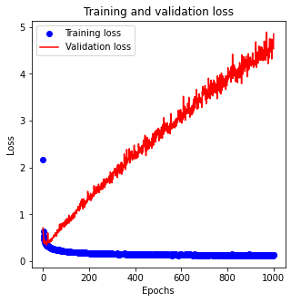

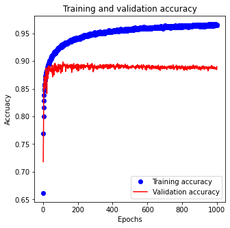

```python
#Evaluating model over training and validation dataset
acc = history_trial_03.history['accuracy']
val_acc = history_trial_03.history['val_accuracy']
loss = history_trial_03.history['loss']
val_loss = history_trial_03.history['val_loss']

print("Average training accuracy across all epochs is",format(round(sum(acc)/len(acc),4)))
print("Average validation accuracy across all epochs is",format(round(sum(val_acc)/len(val_acc),4)))


#Plotting training and validation loss with number of epochs
plt.figure(figsize=(5, 5))
epochs = range(1, len(loss) + 1)
plt.plot(epochs, loss, 'bo', label='Training loss')
plt.plot(epochs, val_loss, 'b', label='Validation loss', color = 'red')
plt.title('Training and validation loss')
plt.xlabel('Epochs')
plt.ylabel('Loss')
plt.legend()
plt.show()

#Plotting training and validation accuracy with number of epochs
plt.figure(figsize=(5, 5))
epochs = range(1, len(acc) + 1)
plt.plot(epochs, acc, 'bo', label='Training accuracy')
plt.plot(epochs, val_acc, 'b', label='Validation accuracy', color = 'red')
plt.title('Training and validation accuracy')
plt.xlabel('Epochs')
plt.ylabel('Accruacy')
plt.legend()
plt.show()
```

```python
trial_03_eval = trial_03.evaluate(test_images, test_labels)
```

##### 4 Trial model - Dropout at 0.1 rate with 2 hidden layers

```python
trial_04 = keras.models.Sequential([
keras.layers.Dense(256, activation="relu",input_shape=[28*28]),
keras.layers.Dropout(rate=0.1),
keras.layers.Dense(256, activation="relu"),
keras.layers.Dropout(rate=0.1),
keras.layers.Dense(10, activation="softmax")
])


trial_04.compile(optimizer=optimizers.Adam(lr=0.01),
              loss='categorical_crossentropy',
              metrics=['accuracy'])
```

```python
trial_04.summary()
```

```
Model: "sequential_67"
_________________________________________________________________
Layer (type)                 Output Shape              Param #
=================================================================
dense_195 (Dense)            (None, 256)               200960
_________________________________________________________________
dropout_78 (Dropout)         (None, 256)               0
_________________________________________________________________
dense_196 (Dense)            (None, 256)               65792
_________________________________________________________________
dropout_79 (Dropout)         (None, 256)               0
_________________________________________________________________
dense_197 (Dense)            (None, 10)                2570
=================================================================
Total params: 269,322
Trainable params: 269,322
Non-trainable params: 0
_________________________________________________________________
```

```python
keras.utils.plot_model(model)
```

```python
history_trial_04 = trial_04.fit(train_dataset,
                    epochs = 1000,
                    validation_data=val_dataset,
                    callbacks=[tensorboard])
```

```
Average training accuracy across all epochs is 0.9323
Average validation accuracy across all epochs is 0.8852
```

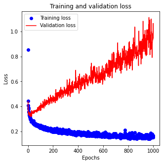

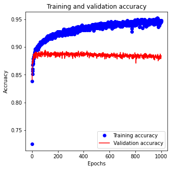

```python
#Evaluating model over training and validation dataset
acc = history_trial_04.history['accuracy']
val_acc = history_trial_04.history['val_accuracy']
loss = history_trial_04.history['loss']
val_loss = history_trial_04.history['val_loss']

print("Average training accuracy across all epochs is",format(round(sum(acc)/len(acc),4)))
print("Average validation accuracy across all epochs is",format(round(sum(val_acc)/len(val_acc),4)))


#Plotting training and validation loss with number of epochs
plt.figure(figsize=(5, 5))
epochs = range(1, len(loss) + 1)
plt.plot(epochs, loss, 'bo', label='Training loss')
plt.plot(epochs, val_loss, 'b', label='Validation loss', color = 'red')
plt.title('Training and validation loss')
plt.xlabel('Epochs')
plt.ylabel('Loss')
plt.legend()
plt.show()

#Plotting training and validation accuracy with number of epochs
plt.figure(figsize=(5, 5))
epochs = range(1, len(acc) + 1)
plt.plot(epochs, acc, 'bo', label='Training accuracy')
plt.plot(epochs, val_acc, 'b', label='Validation accuracy', color = 'red')
plt.title('Training and validation accuracy')
plt.xlabel('Epochs')
plt.ylabel('Accruacy')
plt.legend()
plt.show()
```

```python
trial_04_eval = trial_04.evaluate(test_images, test_labels)
```

##### 5 Trial model - Regularisation l2 and Gradient clipping

```python
trial_05 = keras.models.Sequential([
keras.layers.Dense(256, activation="relu",input_shape=[28*28],kernel_regularizer=keras.regularizers.l2(0.001)),
keras.layers.Dense(256, activation="relu",kernel_regularizer=keras.regularizers.l2(0.001)),
keras.layers.Dense(10, activation="softmax")
])

trial_05.compile(optimizer=optimizers.Adam(lr=0.001, clipnorm=1.0),
              loss='categorical_crossentropy',
              metrics=['accuracy'])
```

```python
trial_05.summary()
```

[output not shown]

```python
keras.utils.plot_model(model)
```

```python
history_trial_05 = trial_05.fit(train_dataset,
                    epochs = 1000,
                    validation_data=val_dataset,
                    callbacks=[tensorboard])
```

```
Average training accuracy across all epochs is 0.9558
Average validation accuracy across all epochs is 0.8856
```

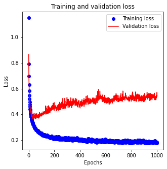

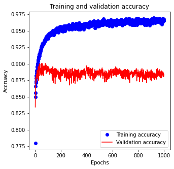

```python
#Evaluating model over training and validation dataset
acc = history_trial_05.history['accuracy']
val_acc = history_trial_05.history['val_accuracy']
loss = history_trial_05.history['loss']
val_loss = history_trial_05.history['val_loss']

print("Average training accuracy across all epochs is",format(round(sum(acc)/len(acc),4)))
print("Average validation accuracy across all epochs is",format(round(sum(val_acc)/len(val_acc),4)))


#Plotting training and validation loss with number of epochs
plt.figure(figsize=(5, 5))
epochs = range(1, len(loss) + 1)
plt.plot(epochs, loss, 'bo', label='Training loss')
plt.plot(epochs, val_loss, 'b', label='Validation loss', color = 'red')
plt.title('Training and validation loss')
plt.xlabel('Epochs')
plt.ylabel('Loss')
plt.legend()
plt.show()

#Plotting training and validation accuracy with number of epochs
plt.figure(figsize=(5, 5))
epochs = range(1, len(acc) + 1)
plt.plot(epochs, acc, 'bo', label='Training accuracy')
plt.plot(epochs, val_acc, 'b', label='Validation accuracy', color = 'red')
plt.title('Training and validation accuracy')
plt.xlabel('Epochs')
plt.ylabel('Accruacy')
plt.legend()
plt.show()
```

```python
trial_05_eval = trial_05.evaluate(test_images, test_labels)
```

##### 6 Trial model - Regularisation l2, Gradient clipping and 70 epochs

From above trial model, number of epochs for robust fit is approximately 70.

```python
trial_06 = keras.models.Sequential([
keras.layers.Dense(256, activation="relu",input_shape=[28*28],kernel_regularizer=keras.regularizers.l2(0.001)),
keras.layers.Dense(256, activation="relu",kernel_regularizer=keras.regularizers.l2(0.001)),
keras.layers.Dense(10, activation="softmax")
])

trial_06.compile(optimizer=optimizers.Adam(lr=0.001, clipnorm=1.0),
              loss='categorical_crossentropy',
              metrics=['accuracy'])


history_trial_06 = trial_06.fit(train_dataset,
                    epochs = 70,
                    validation_data=val_dataset,
                    callbacks=[tensorboard])
```

```
Average training accuracy across all epochs is 0.9076
Average validation accuracy across all epochs is 0.89
```

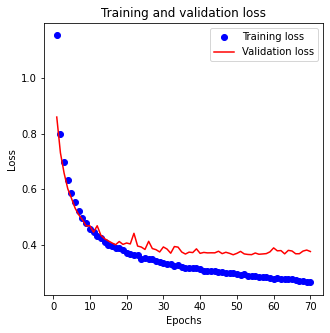

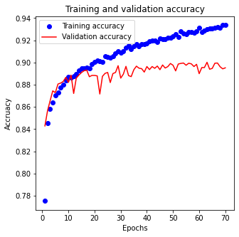

```python
#Evaluating model over training and validation dataset
acc = history_trial_06.history['accuracy']
val_acc = history_trial_06.history['val_accuracy']
loss = history_trial_06.history['loss']
val_loss = history_trial_06.history['val_loss']

print("Average training accuracy across all epochs is",format(round(sum(acc)/len(acc),4)))
print("Average validation accuracy across all epochs is",format(round(sum(val_acc)/len(val_acc),4)))


#Plotting training and validation loss with number of epochs
plt.figure(figsize=(5, 5))
epochs = range(1, len(loss) + 1)
plt.plot(epochs, loss, 'bo', label='Training loss')
plt.plot(epochs, val_loss, 'b', label='Validation loss', color = 'red')
plt.title('Training and validation loss')
plt.xlabel('Epochs')
plt.ylabel('Loss')
plt.legend()
plt.show()

#Plotting training and validation accuracy with number of epochs
plt.figure(figsize=(5, 5))
epochs = range(1, len(acc) + 1)
plt.plot(epochs, acc, 'bo', label='Training accuracy')
plt.plot(epochs, val_acc, 'b', label='Validation accuracy', color = 'red')
plt.title('Training and validation accuracy')
plt.xlabel('Epochs')
plt.ylabel('Accruacy')
plt.legend()
plt.show()
```

```python
trial_06_eval = trial_06.evaluate(test_images, test_labels)
```

[figure not shown]

## **Task 6 Generate HTML output**

```python
jupyter nbconvert --to html notebook.ipynb
```